# BIMM 143 Project 3

# Effects of different cannabinoids on activated microglia transcription of a few key genes

### BIMM 143 Project 3: Daniel Naranjo Sampson

## Scientific Question:

What will be the difference in gene expression between CBD and THC interactions with microglia in their different immune activation states?

Analysis will involve looking at a couple key genes involved in inflammatory processes including nitric oxide synthase and the CB2 receptor and seeing how their expressions are altered across the five total conditions.

## Background info on the data

We’re looking at Microarray data for Mus musculus BV-2 microglia cells in different conditions. These immune cells are activated with lipopolysaccharide (LPS), which is a pathogen-associated molecular pattern (PAMP) for bacterial infection. In other words, the microglia applied with LPS shoud react as if there were a pathogen nearby.

This study basically looks at the differential gene expression between these microglial cells with either THC or CBD added in with or without LPS-activation.

The main mode of effect for either cannabinoid will be the CB2 receptor, whose function is typically to increase microglia proliferation in anti-inflammatory way where they produce and release less inflammatory factors like TNFα and free radicals, downregulate certain viral-activated chemokine receptors, and increase release of beneficial factors like BDNF. I should also mention that microglia actually produce their own endocannabinoids (anandamide and 2-acylglycerol aka 2-AG), so some of this signaling is autocrine, so maybe using cannabinoids like THC and CBD as agonists will have some of the same effect as the endocannabinoids in that respect.

For my purposes I’ll only analyze the effect on a few key genes involved in different microglia functions mostly related to the immune response by comparing their expressions across the various conditions. Since my data is partitioned into LPS-up and down regulated gene lists, I’ll chose three from each list plus the CB2 receptor.

- LPS-upregulated genes: Nos2 (iNOS), Il-6, and Ccl2 (also known as MCP-1)
- LPS-downregulated genes: CD28, Cxcr4, Dgkg, and Cnr2 (CB2 endocannabinoid receptor)

#### Necessary Packages

Importing packages we need for the code we’re running. Quite a few of them but the most important ones have to do with our Gene Ontology (GO) and pathway analysis. org.Mm.eg.db, clusterProfiler, DOSE, rWikiPathways, RCy3 all are imports required for that. data.table, ggplot2, ggnewscale are all packages relevant to data selection and visualization, while dplyr is an all-around useful package for working with large datasets.

```r
library(data.table)
library(org.Mm.eg.db)
library(clusterProfiler)
```

```r
library(ggplot2)
library(DOSE)
library(dplyr)
library(rWikiPathways)
```

#### Data Import and formatting

In these next lines here, we import our data from Excel tables as dataframes. On my computer I set my working directory to Downloads; not sure if this will work for you if you don’t have access to the original data. Anyways from there I just format the data: adding in column names and such (which I could’ve done via the header parameter but when I did so, the format of them was simply a bit of a mess).

```r
# Upregulated genes
upreg_genes <- read.csv(file = "FORMATTED_upregulated_genes - Copy - Copy.csv", header=FALSE,stringsAsFactors = FALSE)
colnames(upreg_genes) <- c('geneName','geneDescription','RefSeqID','foldLPS','foldLPS_CBD','foldLPS_THC','foldCBD','foldTHC','log2LPS','log2LPS_CBD','log2LPS_THC','log2CBD','log2THC','CBD_effect2_LPS','THC_effect2_LPS')

# Downregulated genes
downreg_genes <- read.csv(file = "FORMATTED_downreg_genes.csv", header = FALSE, stringsAsFactors = FALSE)
colnames(downreg_genes) <- c('geneName', 'geneDescription', 'RefSeqID','foldLPS','foldLPS_CBD','foldLPS_THC','foldCBD','foldTHC','log2LPS','log2LPS_CBD','log2LPS_THC','log2CBD','log2THC','CBD_effect2_LPS','THC_effect2_LPS')

# Chopping some rows off of downreg_genes because the two empty rows I left in the Excel sheet were annoying me.
downreg_genes <- downreg_genes[-c(1,2),]
```

We have to use a regular expression here to chop off the version numbers from the RefSeq gene IDs because later GO functions just won’t be able to process those. This gsub() function will change a gene ID from something like “NM_013653.1” to “NM_013653” for the Ccl5 gene.

```r
upreg_genes$RefSeqID <- gsub(pattern = "\\.\\d", replacement = "", upreg_genes$RefSeqID)
downreg_genes$RefSeqID <- gsub(pattern = "\\.\\d", replacement = "", downreg_genes$RefSeqID)
```

Now we get to talk about Gene IDs. I’ve had to learn way too much about these recently, so you get to join me in my suffering. There’s a ton of ways to ID any one gene, between the various naming conventions, languages, inconsistent acronym usage, and of course whether we’re talking DNA, mRNA or protein, even the specific country we’re in — it’s just too much man. So bioinformaticians have made specific codes for each individual gene, and these follow various formats or ‘keyTypes’ depending on the database being used.

If you’re curious about these keyTypes, use this function below to find out how many there are just for mice.

```r
keytypes(org.Mm.eg.db)
```

```
##  [1] "ACCNUM"       "ALIAS"        "ENSEMBL"      "ENSEMBLPROT"  "ENSEMBLTRANS"
##  [6] "ENTREZID"     "ENZYME"       "EVIDENCE"     "EVIDENCEALL"  "GENENAME"
## [11] "GO"           "GOALL"        "IPI"          "MGI"          "ONTOLOGY"
## [16] "ONTOLOGYALL"  "PATH"         "PFAM"         "PMID"         "PROSITE"
## [21] "REFSEQ"       "SYMBOL"       "UNIGENE"      "UNIPROT"
```

NCBI and the paper I pull the microarray data from use RefSeq formats, and my GO packages require EntrezIDs, so I use and specifically the bitr() function within the clusterProfiler package to convert my gene lists.

So let’s do that.

```r
up.genes.entrez <- clusterProfiler::bitr(upreg_genes$RefSeqID, fromType = "REFSEQ", toType = "ENTREZID", OrgDb = org.Mm.eg.db, drop = FALSE)
down.genes.entrez <- clusterProfiler::bitr(downreg_genes$RefSeqID,  fromType = "REFSEQ", toType = "ENTREZID", OrgDb = org.Mm.eg.db, drop = FALSE)
```

Now we have our dataframes for up and downregulated genes under the LPS-alone condition, as well as genelists in EntrezID formats to work with.

#### Gene Ontology

Now it’s time for the gene ontology itself. Here, we’re using the clusterProfiler package again, but now it’s the groupGO() function. This part also uses dependencies within the DOSE package for the geneList dataset. Also I’m sorting the data within each column before doing anything, although I don’t remember 100% why that was necessary.

You can see the data output from this if you run the head() functions down below.

```r
order(up.genes.entrez$ENTREZID, decreasing = TRUE)
```

```
##   [1] 148 130 183 131 104 105 117  72 144  26  99 181  93 100  52 145  92  58
##  [19]  40  50 146  33 122 169  83  45  17  53  73  81  88  95 114   9  82  67
##  [37] 143 160  75  28  36   8 125  64 180  34 171 163  86  39  54 120 165 150
##  [55]  94  79  91  25  14 110 109   3 178 179  80  29 175 177  69 140 182 156
##  [73] 119  27  30  96 151 138  90 153  15  22  20  18  21  23  19  55 121 123
##  [91] 134 102  61 106  98 128 159 157  97 162  11  41 103 158  65 124 133 126
## [109] 127 129  57  70 147 173  24 172  89 166  35 108 135 136 155  44   6   1
## [127]   5  10  12  13  46  43  48  42  51  16  49  60 154  62  77  76  74  78
## [145] 170 137   7  68 111 161  87  59 101 141   2 164 149  32  31 142 139  56
## [163] 113  66  38 115 112 132 152 107 167  63 174 116 168  47   4  37  71  84
## [181]  85 118 176 184
```

```r
order(down.genes.entrez$ENTREZID, decreasing = TRUE)
```

```
##  [1] 11  4 51 22 62  5 53 73  8 17 36  9  3 15 49 71 64 32 42 59 78 16 13 31 38
## [26] 20 61 37 66 74 40 41 14 34 55 76 46 25 68 60 10 19 50 77 27 72 39 48 44 69
## [51] 75 21 57 81 80 43 67 70 12 63 23 33 35 52  7 26 18 24 58 56  6 30 29 45 28
## [76] 54 47 65  1  2 79
```

```r
upreg_ggo <- clusterProfiler::groupGO(gene = up.genes.entrez$ENTREZID, OrgDb = org.Mm.eg.db)

downreg_ggo <- clusterProfiler::groupGO(gene = down.genes.entrez$ENTREZID, OrgDb = org.Mm.eg.db)

head(upreg_ggo)
```

```
##                    ID                Description Count GeneRatio
## GO:0005622 GO:0005622              intracellular   143   143/177
## GO:0019012 GO:0019012                     virion     0     0/177
## GO:0032991 GO:0032991 protein-containing complex    44    44/177
## GO:0044217 GO:0044217        other organism part     0     0/177
## GO:0044423 GO:0044423                virion part     0     0/177
## GO:0110165 GO:0110165 cellular anatomical entity   171   171/177
##                                                                                                                                                                                                                                                                                                          …
## GO:0005622                                                                                                                                                                           16176/21926/16175/16193/14204/23886/246779/16173/18591/16168…
## GO:0019012
## GO:0032991                                                                                                                                                                                                                                                                                               …
## GO:0044217
## GO:0044423
## GO:0110165 16176/12985/21926/16175/16193/14204/23886/246779/16173/18591…
```

```r
head(downreg_ggo)
```

```
##                    ID                Description Count GeneRatio
## GO:0005622 GO:0005622              intracellular    66     66/78
## GO:0019012 GO:0019012                     virion     0      0/78
## GO:0032991 GO:0032991 protein-containing complex    24     24/78
## GO:0044217 GO:0044217        other organism part     0      0/78
## GO:0044423 GO:0044423                virion part     0      0/78
## GO:0110165 GO:0110165 cellular anatomical entity    75     75/78
##                                                                                                                                                                                                                                                                                                          …
## GO:0005622                                                           53376/98170/76467/11628/12767/67213/57266/20440/98388/14537/…
## GO:0019012
## GO:0032991                                                                                                                                                                                                                                                                                               …
## GO:0044217
## GO:0044423
## GO:0110165 53376/98170/76467/11628/12767/67213/57266/20440/98388/14537/…
```

##### Visualization

At this point, we have our GO analysis mostly done, but we need to visualize it to be sure of what we have. So first we’re going to make some quick barplots for each dataset. They do not show very much detail but they give us a general idea of the gene categories we’re looking at. Also due to the way I did the gene ontologies, ie not separating the gene lists further by upreg/downreg in the various conditions, here we only have our original two categories of LPS-upregulated and LPS-downregulated.

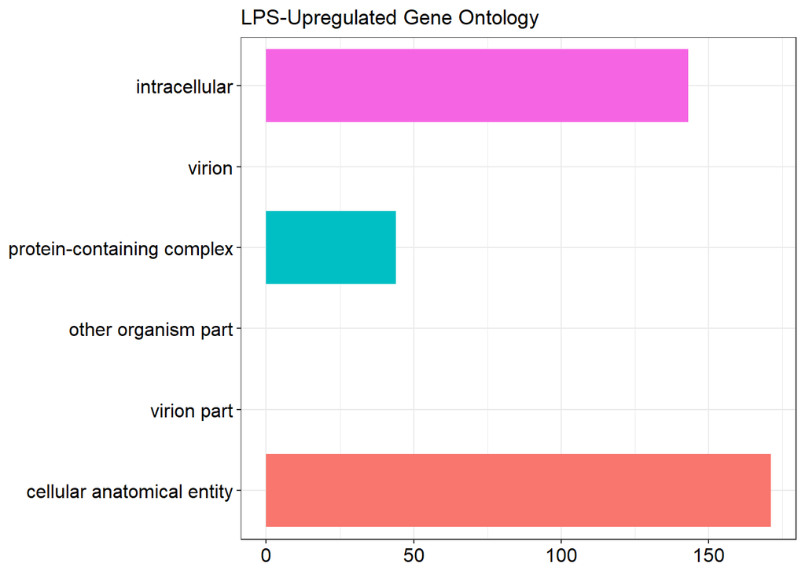

```r
barplot(upreg_ggo, showCategory = 100, title = "LPS-Upregulated Gene Ontology")
```

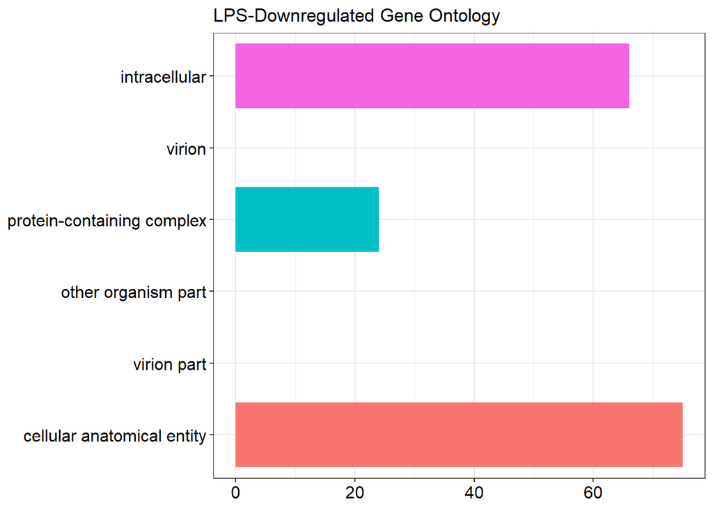

```r
barplot(downreg_ggo, showCategory = 100,title = "LPS-Downregulated Gene Ontology")
```

We can also make Gene Concept Networks, which are networks of genes and the various categories they might belong to. Here we can do one for all five experimental groups we have: LPS, LPS+CBD, LPS+THC, CBD, and THC. But first we’re gonna convert our EntrezIDs to normal gene SYMBOLs using the setReadable() function within DOSE. Symbols are another keyType, however they’re a lot more recognizable to anyone whose studied any genes before because they look like the simple acronyms we see in class and in research papers. Eg. Il-6, Stat1 or NFkB.

```r
up_ggo <- setReadable(upreg_ggo, 'org.Mm.eg.db', 'ENTREZID')
str(up_ggo)
```

```
## Formal class 'groupGOResult' [package "clusterProfiler"] with 15 slots
##   ..@ level        : num 2
##   ..@ result       :'data.frame':    6 obs. of  5 variables:
##   .. ..$ ID         : chr [1:6] "GO:0005622" "GO:0019012" "GO:0032991" "GO:0044217" ...
##   .. ..$ Description: chr [1:6] "intracellular" "virion" "protein-containing complex" "other organism part" ...
##   .. ..$ Count      : int [1:6] 143 0 44 0 0 171
##   .. ..$ GeneRatio  : chr [1:6] "143/177" "0/177" "44/177" "0/177" ...
##   .. ..$ geneID     : chr [1:6] "Il1b/Tnf/Il1a/Il6/Il4i1/Gdf15/Il27/Il18/Pdgfb/Il15/Il10ra/Ccrl2/Ccl5/Ccl2/Traf1/Irak3/Stat2/Malt1/Nlrp3/Stat1/S"| __truncated__ "" "Il6/Traf1/Malt1/Nlrp3/Stat1/Cish/Socs3/Ddx58/Lcp2/Bcl3/Zfp36/Isg15/Ifitm3/Saa3/Cd69/Ptgs2/Hp/C3/Tap1/Tlr2/Gch1/"| __truncated__ "" .…
##   ..@ pvalueCutoff : num(0)
##   ..@ pAdjustMethod: chr(0)
##   ..@ qvalueCutoff : num(0)
##   ..@ organism     : chr "Mus musculus"
##   ..@ ontology     : chr "CC"
##   ..@ gene         : chr [1:184] "16176" "12985" "21926" NA ...
##   ..@ keytype      : chr "ENTREZID"
##   ..@ universe     : chr(0)
##   ..@ gene2Symbol  : Named chr [1:177] "Il1b" "Csf3" "Tnf" NA ...
##   .. ..- attr(*, "names")= chr [1:177] "16176" "12985" "21926" NA ...
##   ..@ geneSets     : list()
##   ..@ readable     : logi TRUE
##   ..@ termsim      : num[0 , 0 ]
##   ..@ method       : chr(0)
```

```r
dn_ggo <- setReadable(downreg_ggo, 'org.Mm.eg.db', 'ENTREZID')
str(dn_ggo)
```

```
## Formal class 'groupGOResult' [package "clusterProfiler"] with 15 slots
##   ..@ level        : num 2
##   ..@ result       :'data.frame':    6 obs. of  5 variables:
##   .. ..$ ID         : chr [1:6] "GO:0005622" "GO:0019012" "GO:0032991" "GO:0044217" ...
##   .. ..$ Description: chr [1:6] "intracellular" "virion" "protein-containing complex" "other organism part" ...
##   .. ..$ Count      : int [1:6] 66 0 24 0 0 75
##   .. ..$ GeneRatio  : chr [1:6] "66/78" "0/78" "24/78" "0/78" ...
##   .. ..$ geneID     : chr [1:6] "Usp2/Tmem132a/Msrb2/Aicda/Cxcr4/Cmtm6/Cxcl14/St6gal1/Chst10/Gcnt1/Zdhhc14/Nanos1/Rasgrp3/Midn/Ccnd1/Kmt5c/Smad3"| __truncated__ "" "Aicda/Cxcr4/Rasgrp3/Ccnd1/Smad3/Bcl9l/Eps8/Zfp36l1/Cd28/Acvr2b/Mertk/E2f2/Sox4/Lbh/Fbxw4/Zfpm1/Meis1/Hdac5/Cbx8"| __truncated__ "" .…
##   ..@ pvalueCutoff : num(0)
##   ..@ pAdjustMethod: chr(0)
##   ..@ qvalueCutoff : num(0)
##   ..@ organism     : chr "Mus musculus"
##   ..@ ontology     : chr "CC"
##   ..@ gene         : chr [1:81] NA NA "53376" "98170" ...
##   ..@ keytype      : chr "ENTREZID"
##   ..@ universe     : chr(0)
##   ..@ gene2Symbol  : Named chr [1:78] NA "Usp2" "Tmem132a" "Msrb2" ...
##   .. ..- attr(*, "names")= chr [1:78] NA "53376" "98170" "76467" ...
##   ..@ geneSets     : list()
##   ..@ readable     : logi TRUE
##   ..@ termsim      : num[0 , 0 ]
##   ..@ method       : chr(0)
```

```r
# Upreg genes first
up_genes_LPS <- cnetplot(up_ggo, foldChange = upreg_genes$foldLPS,
                         colorEdge = TRUE,
                         cex_gene = 1,cex_label_gene = .5,
                         cex_label_category = .01,
                         cex_category = .1) + ggtitle("Upreg genes: LPS only")

up_genes_LPS_CBD <- cnetplot(up_ggo, foldChange = upreg_genes$foldLPS_CBD,
                         colorEdge = TRUE,
                         cex_gene = 1,cex_label_gene = .5,
                         cex_label_category = .01,
                         cex_category = .1) + ggtitle("Upreg genes: LPS + CBD")

up_genes_LPS_THC <- cnetplot(up_ggo, foldChange = upreg_genes$foldLPS_THC,
                         colorEdge = TRUE,
                         cex_gene = 1,cex_label_gene = .5,
                         cex_label_category = .01,
                         cex_category = .1) + ggtitle("Upreg genes: LPS + THC")

up_genes_CBD <- cnetplot(up_ggo, foldChange = upreg_genes$foldCBD,
                         colorEdge = TRUE,
                         cex_gene = 1,cex_label_gene = .5,
                         cex_label_category = .01,
                         cex_category = .1) + ggtitle("Upreg genes: CBD only")

up_genes_THC <- cnetplot(up_ggo, foldChange = upreg_genes$foldTHC,
                         colorEdge = TRUE,
                         cex_gene = 1,cex_label_gene = .5,
                         cex_label_category = .01,
                         cex_category = .1) + ggtitle("Upreg genes: THC only")


# Downreg genes
down_genes_LPS <- cnetplot(dn_ggo, foldChange = downreg_genes$foldLPS,
                           colorEdge = TRUE,
                           cex_gene = 1,cex_label_gene = .5,
                           cex_label_category = .01,
                           cex_category = .1) + ggtitle("Downreg genes: LPS only")

down_genes_LPS_CBD <- cnetplot(dn_ggo, foldChange = downreg_genes$foldLPS_CBD,
                             colorEdge = TRUE,
                             cex_gene = 1,cex_label_gene = .5,
                             cex_label_category = .01,
                             cex_category = .1) + ggtitle("Downreg genes: LPS + CBD")

down_genes_LPS_THC <- cnetplot(dn_ggo, foldChange = downreg_genes$foldLPS_THC,
                             colorEdge = TRUE,
                             cex_gene = 1,cex_label_gene = .5,
                             cex_label_category = .01,
                             cex_category = .1) + ggtitle("Downreg genes: LPS + THC")

down_genes_CBD <- cnetplot(dn_ggo, foldChange = downreg_genes$foldCBD,
                           colorEdge = TRUE,
                           cex_gene = 1,cex_label_gene = .5,
                           cex_label_category = .01,
                           cex_category = .1) + ggtitle("Downreg genes: CBD only")

down_genes_THC <- cnetplot(dn_ggo, foldChange = downreg_genes$foldTHC,
                           colorEdge = TRUE,
                           cex_gene = 1,cex_label_gene = .5,
                           cex_label_category = .01,
                           cex_category = .1) + ggtitle("Downreg genes: THC only")
```

We can look at the fruits of our hard labor by simply calling any one of these new cnetplot() objects we’ve created. These plots are honestly super cool so I recommend you go through each one individually.

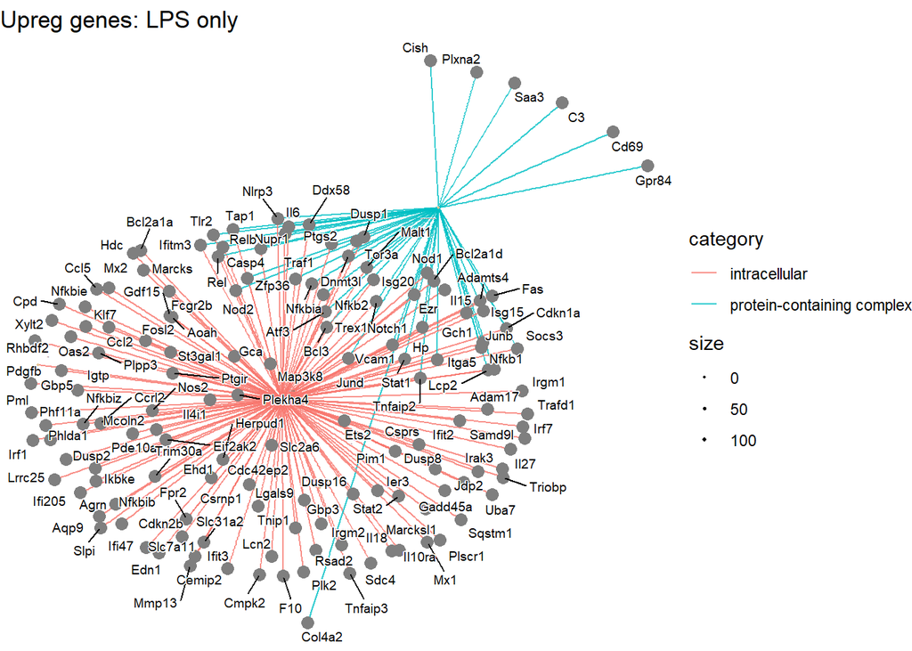

```r
up_genes_LPS
```

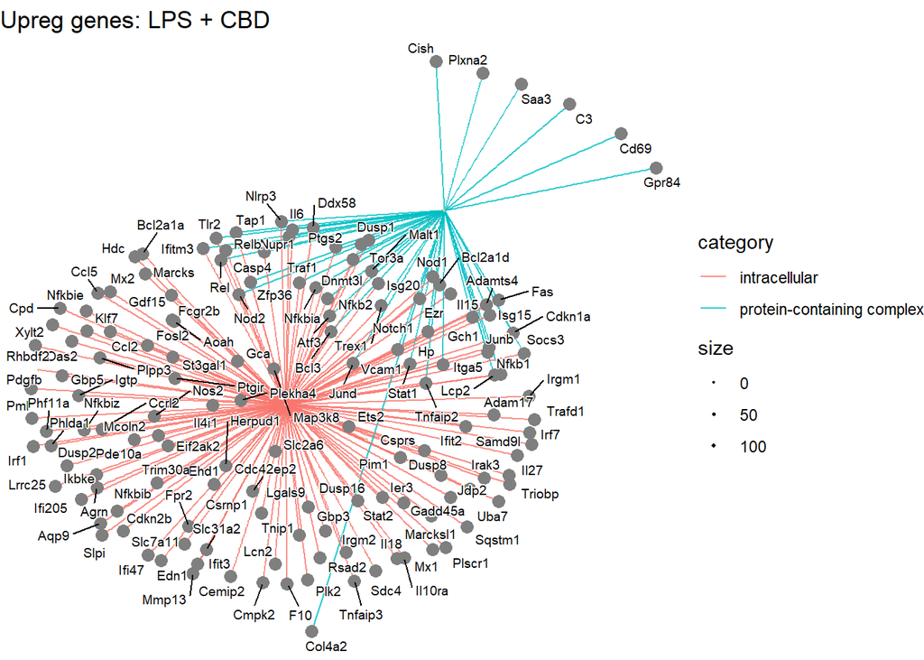

```r
up_genes_LPS_CBD
```

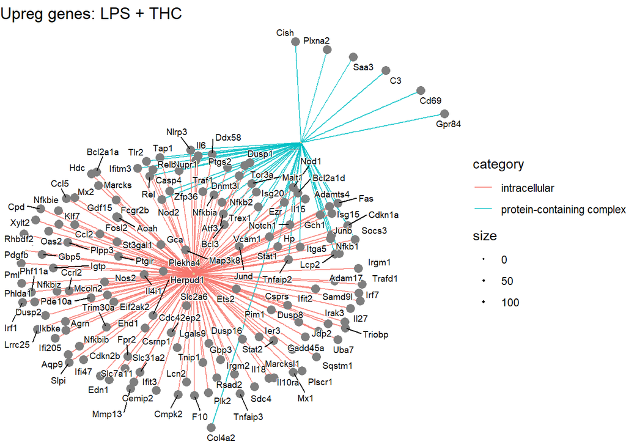

```r
up_genes_LPS_THC
```

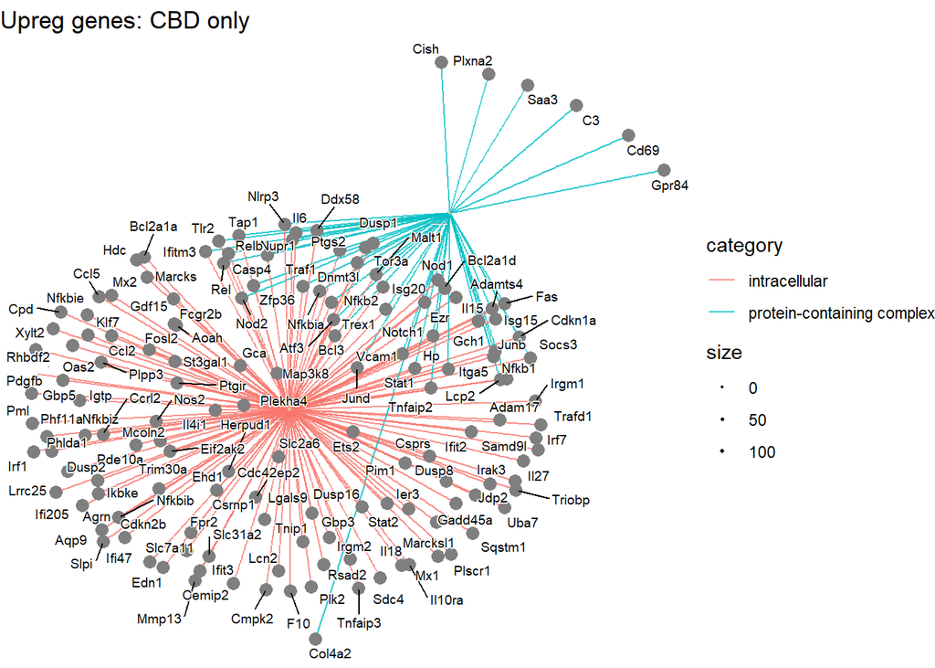

```r
up_genes_CBD
```

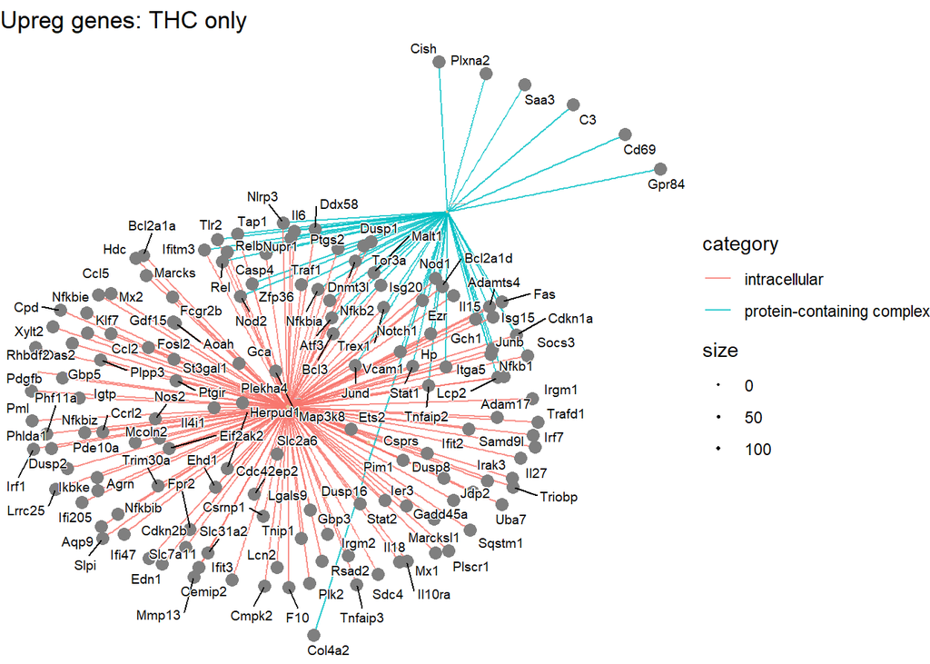

```r
up_genes_THC
```

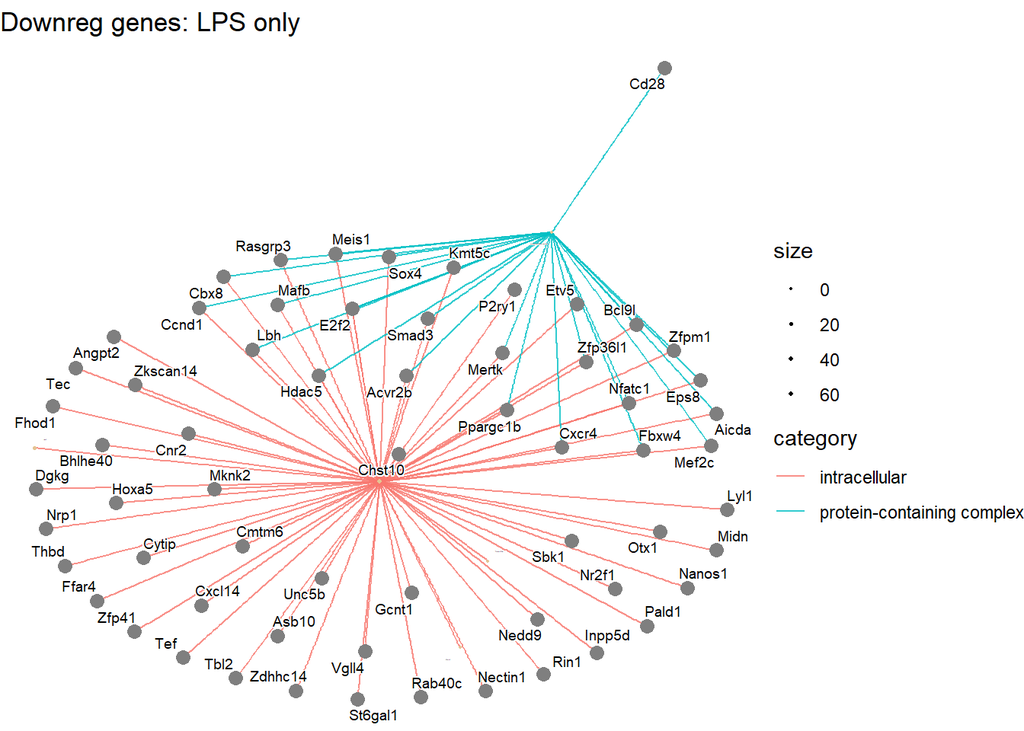

```r
down_genes_LPS
```

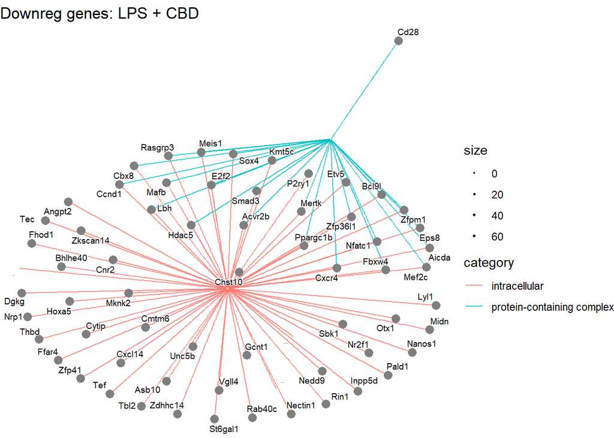

```r
down_genes_LPS_CBD
```

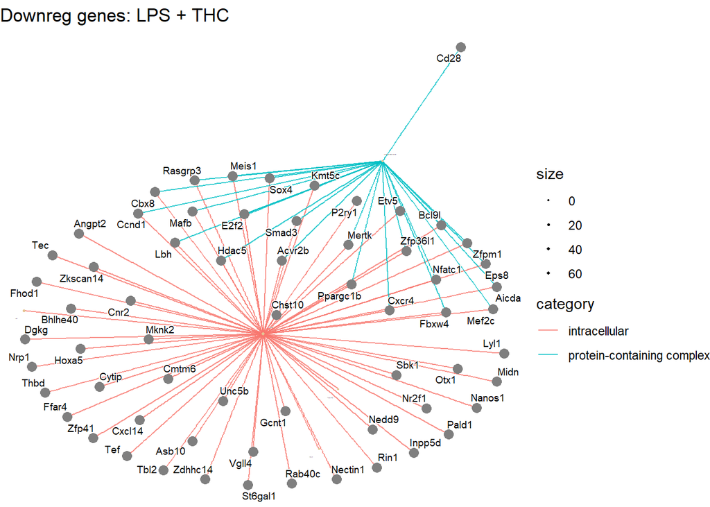

```r
down_genes_LPS_THC
```

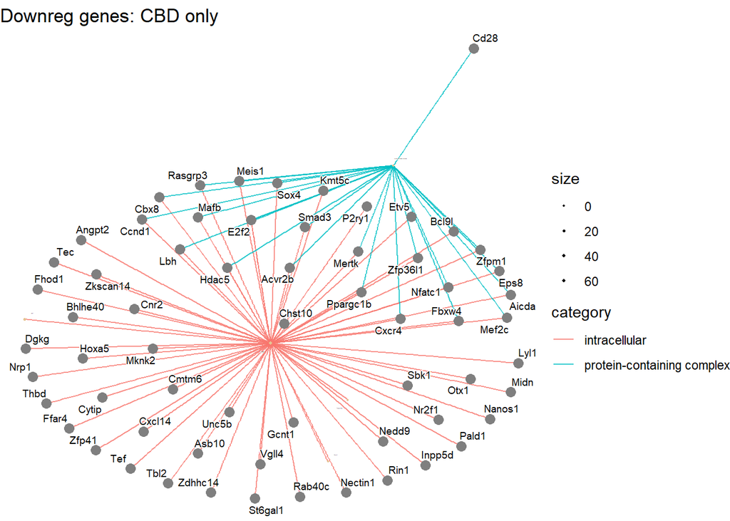

```r
down_genes_CBD
```

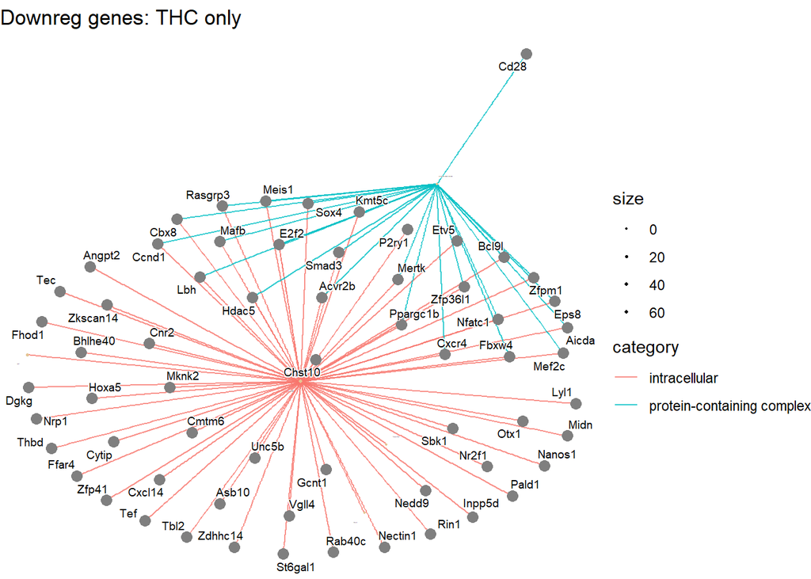

```r
down_genes_THC
```

### Results and Analysis

So we got all these fine-looking plots right here. Lots of good stuff to be analyzed here; but not by me. Not today. I’ll just stick to my original objective and comparing the expression profiles of our seven target genes. The objective now is then to pull those values from our up_ggo and down_ggo results lists. For that, we’ll make a some vectors of the genes we’re looking for and use a dplyr filter on our original gene dataframes to retrieve their data…

Or I would if I could on both gene lists. Upreg_genes is coming up with “Error: Can’t transform a data frame with duplicate names” when there literally no duplicate rownames anywhere (I checked manually)… so after hours of testing other solutions I have to hardcode this in. This might take the cake for the stupidest and most inconvenient error I’ve ever found in my 5 years of programming.

```r
geneName <- c("Nos2", "Il6", "Ccl2")
RefSeqID <- c("NM_010927" ,"NM_031168","NM_011333")
foldLPS <- c(upreg_genes[4,65],upreg_genes[4,6],upreg_genes[4,23])
foldLPS_CBD <- c(upreg_genes[5,65],upreg_genes[5,6],upreg_genes[5,23])
foldLPS_THC <- c(upreg_genes[6,65],upreg_genes[6,6],upreg_genes[6,23])
foldCBD <- c(upreg_genes[7,65],upreg_genes[7,6],upreg_genes[7,23])
foldTHC <- c(upreg_genes[8,65],upreg_genes[8,6],upreg_genes[8,23])

up_target_jeans <- data.frame(geneName,RefSeqID,foldLPS,foldLPS_CBD,foldLPS_THC,foldCBD,foldTHC)

up_target_jeans
```

[output not shown]

```r
dn_target_jeans <- filter(downreg_genes, geneName %in% c("Cd28","Cxcr4", "Dgkg", "Cnr2"))
dn_target_jeans <- subset(dn_target_jeans, select=-c(2,9:18))
dn_target_jeans$RefSeqID <- gsub(pattern = "\\.\\d", replacement = "", dn_target_jeans$RefSeqID)

target_genes <- rbind(up_target_jeans, dn_target_jeans)
```

Now that we have a new dataframe with only our genes of interest, we can just do a quick comparison across all the genes listed

```r
target_genes_entrez <- clusterProfiler::bitr(target_genes$RefSeqID, fromType = "REFSEQ", toType = "ENTREZID", OrgDb = org.Mm.eg.db, drop = FALSE)
target_genes <- cbind(target_genes,target_genes_entrez)
order(target_genes$ENTREZID, decreasing = TRUE)
```

```
## [1] 3 1 2 7 4 5 6
```

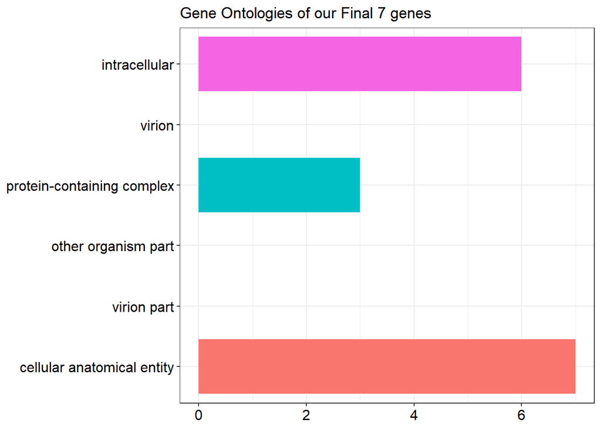

```r
final_ggo <- clusterProfiler::groupGO(gene = target_genes$ENTREZID, OrgDb = org.Mm.eg.db)
final_ggo@readable = TRUE

barplot(final_ggo) + ggtitle("Gene Ontologies of our Final 7 genes")
```

And that’s that! Here are some links to the original papers: - Data from: https://www.ncbi.nlm.nih.gov/pmc/articles/PMC3634783/#!po=1.02041 - Background from: https://www.ncbi.nlm.nih.gov/pmc/articles/PMC2828614/ and https://www.frontiersin.org/articles/10.3389/fnmol.2017.00191/full, https://www.liebertpub.com/doi/10.1089/can.2018.0073 - Tutorial that I followed: https://bioconductor.org/packages/release/bioc/vignettes/rWikiPathways/inst/doc/Pathway-Analysis.html#4_Enrichment - Documentation for clusterProfiler: https://www.bioconductor.org/packages/devel/bioc/manuals/clusterProfiler/man/clusterProfiler.pdf, http://yulab-smu.top/clusterProfiler-book/index.html